# Lecture 2 – Matrix Representation of Texts, and Visualization

SIMP59: Data Selection and Visualisation 2026

nils.holmberg@iko.lu.se

## Presentation

- Nils Holmberg
- Computational  
  content analysis
- Cognitive  
  communication effects

[video not shown]

## Course literature

[figure not shown]

Silge and Robinson (2017)

[figure not shown]

Wickham, Çetinkaya-Rundel, and Grolemund (2023)

[figure not shown]

Wilke (2019)

## Lecture overview

- `Word frequency, TF-IDF`
- Relative frequency
- Important terms
- `Document-term matrix, DTM`
- Bag-of-words
- Word embeddings
- `Topic modeling`
- Minimal example
- Contrasting topics
- `Scale up, Intro lab 2`
- Example text corpus
- Visualizing topics

## Assignment 1: Select text data

- `Data selection`
- 10 plain text documents
- Mini-corpus, text collection
- Scale up for thesis work
- Social media, books
- Web pages, communication
- [Example dataset](https://www.kaggle.com/datasets/nilsholmberg/cca-comm)
- Work in RStudio/Positron!

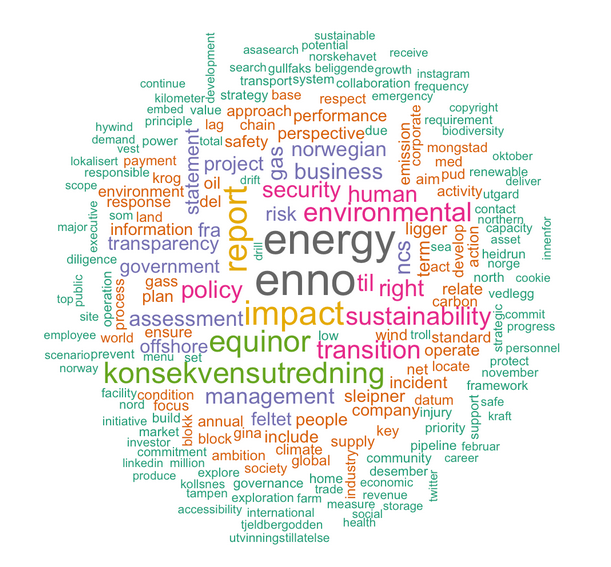

Word frequency,  
TF-IDF

## Why Use TF-IDF?

#### Analyzing word and document frequency: tf-idf

- Raw counts overvalue common words.
- `tf` measures within-document frequency.
- `idf` downweights corpus-wide words.
- `tf-idf = tf * idf` balances both.
- Goal: find words specific to a document.

| measure | meaning |
| --- | --- |
| tf | How often a term appears in one document |
| idf | How rare the term is across all documents |
| tf-idf | Importance score for that document |

## Build Term Frequency for Austen Novels

#### Analyzing word and document frequency: tf-idf

- Tokenize text into words.
- Count `n` by `book` and `word`.
- Compute total words per book.
- Convert to relative frequency `n / total`.
- Keep tidy rows for easy plotting.

| book | word | n | total | term_frequency |
| --- | --- | --- | --- | --- |
| Mansfield Park | the | 6206 | 160460 | 0.0386763 |
| Mansfield Park | to | 5475 | 160460 | 0.0341207 |
| Mansfield Park | and | 5438 | 160460 | 0.0338901 |
| Emma | to | 5239 | 160996 | 0.0325412 |
| Emma | the | 5201 | 160996 | 0.0323052 |

## Read the Long-Tail Pattern

#### Analyzing word and document frequency: tf-idf

- Most words are rare in each book.
- A few words appear very often.
- This creates a long right tail.
- Pattern is similar across novels.
- Frequency alone misses specificity.

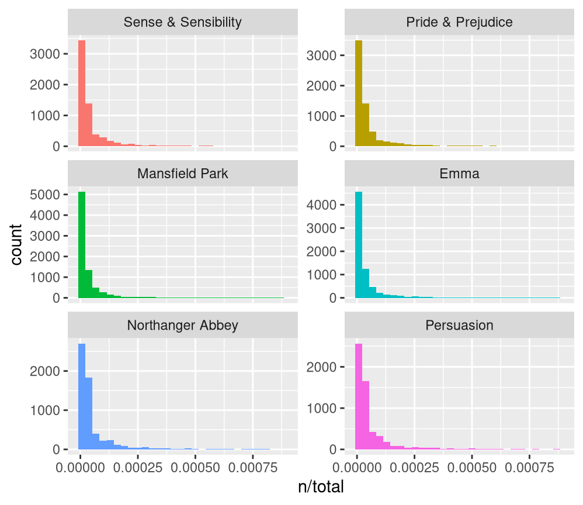

## Compute TF-IDF with `bind_tf_idf()`

#### Analyzing word and document frequency: tf-idf

- Input needs `term`, `document`, `count`.
- Function adds `tf`, `idf`, `tf_idf`.
- Very common words get low idf.
- Rare but frequent-in-doc words rise.
- Output stays in tidy format.

| book | word | tf | idf | tf_idf |
| --- | --- | --- | --- | --- |
| Sense & Sensibility | elinor | 0.0051935 | 1.791759 | 0.0093056 |
| Sense & Sensibility | marianne | 0.0041015 | 1.791759 | 0.0073488 |
| Mansfield Park | crawford | 0.0030724 | 1.791759 | 0.0055050 |
| Pride & Prejudice | darcy | 0.0030523 | 1.791759 | 0.0054689 |
| Persuasion | elliot | 0.0030362 | 1.791759 | 0.0054401 |

## Interpret High TF-IDF in Austen

#### Analyzing word and document frequency: tf-idf

- Top words are mostly proper nouns.
- Names separate one novel from others.
- Shared function words move to the bottom.
- TF-IDF captures document distinctiveness.
- This supports close-reading hypotheses.

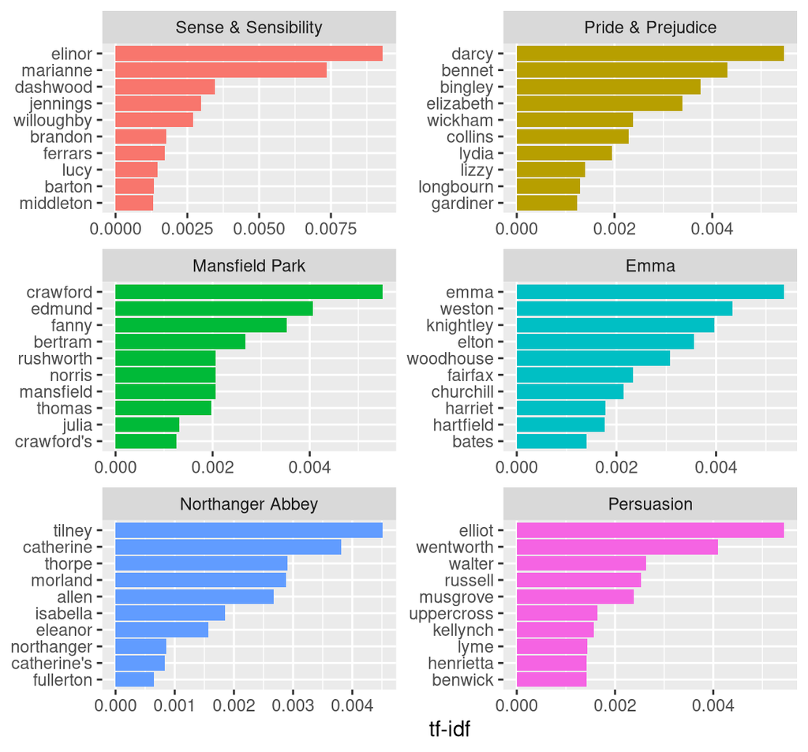

## Transfer the Method to Physics Texts

#### Analyzing word and document frequency: tf-idf

- Use author as document label.
- Count words per author text.
- Compute tf-idf across authors.
- Compare top words by author facet.
- Domain differences appear quickly.

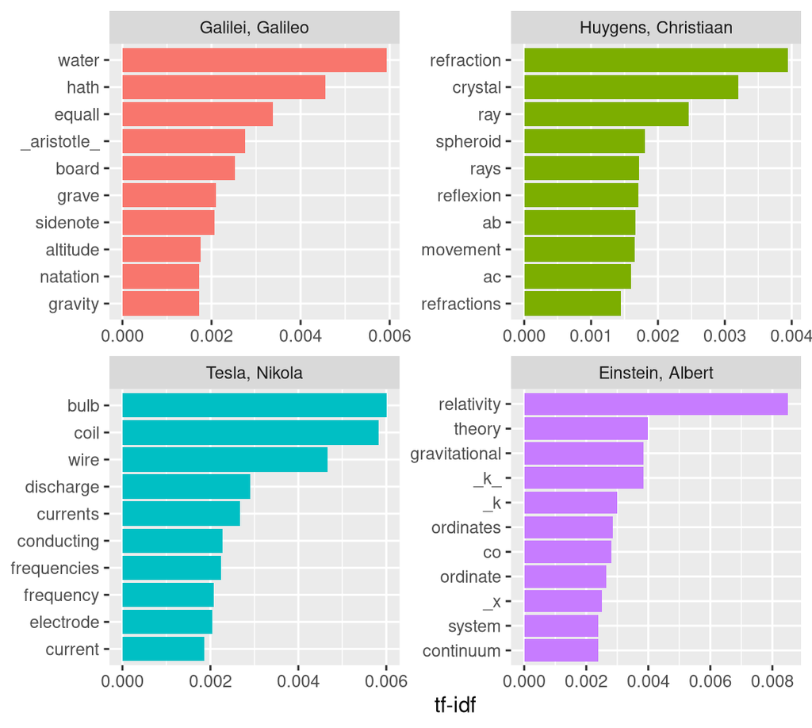

## Clean Artifacts Before Final Interpretation

#### Analyzing word and document frequency: tf-idf

- Some tokens are formatting artifacts.
- Build a custom stopword list.
- Remove noise with `anti_join()`.
- Recompute tf-idf after cleaning.
- Interpret content terms with more trust.

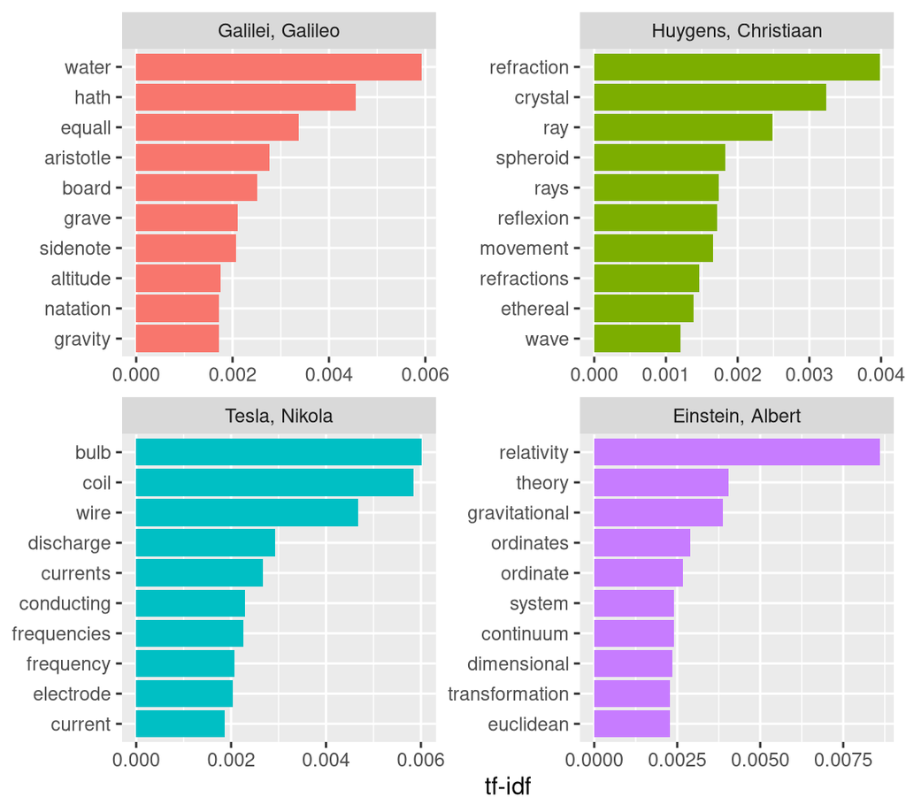

## Key Takeaways

#### Analyzing word and document frequency: tf-idf

- Start with term-frequency diagnostics.
- Use tf-idf to compare documents fairly.
- Inspect high-weight terms by category.
- Clean artifacts, then rerun analysis.
- Pair scores with qualitative reading.

| step | outcome |
| --- | --- |
| Tokenize and count | Tidy term-document counts |
| Check frequency shape | Understand baseline language |
| Compute tf-idf | Document-specific signals |
| Visualize top terms | Fast cross-document insight |
| Clean and iterate | More credible interpretation |

Document-term  
matrix, DTM

## Definition of a Text Matrix

- A text matrix converts language into numerical form.
- It organizes text as rows x columns.
- Rows typically represent documents or words.
- Columns represent features (e.g., terms or dimensions).
- It enables statistical and computational analysis.

| Document | term1 | term2 | term3 |
| --- | --- | --- | --- |
| Doc1 | 2 | 0 | 1 |
| Doc2 | 1 | 3 | 0 |

## Simple Bag-of-Words Model

- Counts how often words appear in a document.
- Ignores word order and grammar.
- Each document becomes a numeric vector.
- Vocabulary is defined at corpus level.
- Forms the basis of many NLP models.

| Document | climate | oil | transition |
| --- | --- | --- | --- |
| Doc1 | 2 | 1 | 1 |
| Doc2 | 0 | 3 | 1 |

## Document-Term Matrix (DTM)

- Rows represent documents.
- Columns represent words (terms).
- Cells contain word frequency or weights.
- Most common matrix representation in NLP.
- Used for classification, clustering, topic modeling.

| Document | climate | energy | oil | transition |
| --- | --- | --- | --- | --- |
| Doc1 | 3 | 1 | 0 | 2 |
| Doc2 | 0 | 2 | 4 | 1 |

## Term-Document Matrix (TDM)

- Transpose of a DTM.
- Rows represent words.
- Columns represent documents.
- Same data, different orientation.
- Useful in mathematical formulations.

| term | Doc1 | Doc2 |
| --- | --- | --- |
| climate | 3 | 0 |
| energy | 1 | 2 |
| oil | 0 | 4 |
| transition | 2 | 1 |

## Binary Matrix (Presence/Absence)

- Records whether a word appears.
- Uses 1 for presence, 0 for absence.
- Ignores frequency intensity.
- Useful for simple similarity measures.
- Often used in lexicon-based analysis.

| Document | climate | oil | transition |
| --- | --- | --- | --- |
| Doc1 | 1 | 1 | 1 |
| Doc2 | 0 | 1 | 1 |

## TF-IDF Matrix

- Weights words by importance.
- Reduces impact of very common words.
- Highlights distinctive terms.
- Combines term frequency and inverse document frequency.
- Widely used in search and retrieval.

| Document | climate | oil | transition |
| --- | --- | --- | --- |
| Doc1 | 0.8 | 0.2 | 0.6 |
| Doc2 | 0.0 | 0.9 | 0.3 |

## Co-Occurrence Matrix

- Rows and columns represent words.
- Cells show how often words appear together.
- Captures semantic relationships.
- Often symmetric.
- Used for semantic networks and framing analysis.

| term | climate | oil | transition |
| --- | --- | --- | --- |
| climate | - | 2 | 5 |
| oil | 2 | - | 1 |
| transition | 5 | 1 | - |

## Embedding Matrix

- Represents words or documents as vectors.
- Rows are tokens or documents.
- Columns are latent dimensions.
- Values are continuous numbers.
- Captures semantic similarity.

| Word | Dim1 | Dim2 | Dim3 |
| --- | --- | --- | --- |
| climate | 0.21 | 0.84 | 0.33 |
| oil | 0.75 | 0.10 | 0.44 |
| transition | 0.40 | 0.65 | 0.29 |

## Why Use a Matrix?

- Enables linear algebra operations.
- Allows similarity computation.
- Supports machine learning models.
- Enables dimensionality reduction.
- Makes large text corpora analyzable.

| Document | Doc1 | Doc2 |
| --- | --- | --- |
| Doc1 | 1.00 | 0.62 |
| Doc2 | 0.62 | 1.00 |

Topic modeling

## pyLDAvis Topic Model

[interactive chart not shown]

## Create a Minimal Tidy Text Dataframe

- We define a compact labeled text dataset.
- Each row is one document headline.
- Document index uses `doc_1`, `doc_2`, `doc_3`.
- This object is the base for tokenization.
- Code focus: `tibble(doc_id, headline)`.

## Create a Minimal Tidy Text Dataframe

df_texts

| doc_id | headline |
| --- | --- |
| doc_1 | City council approves new park plan |
| doc_2 | New park plan faces budget debate |
| doc_3 | Budget debate grows as city park opens |

## Tokenize into df_tokens

- Tokenization splits text into individual words.
- We keep document IDs during the split.
- Tidy output has one token occurrence per row.
- This enables counting and weighting operations.
- Core code: `unnest_tokens(token, headline)`.

## Tokenize into df_tokens

Tokenized rows

| doc_id | token |
| --- | --- |
| doc_1 | city |
| doc_1 | council |
| doc_1 | approves |
| doc_1 | new |
| doc_1 | park |
| doc_1 | plan |
| doc_2 | new |

## Visualize Token Frequencies by Headline

- We count token frequencies within each document.
- Reordered bars improve readability by facet.
- Faceting compares three headlines directly.
- This is the raw-frequency view of vocabulary.
- Core code: `count()` + `ggplot()` + `facet_wrap()`.

## Visualize Token Frequencies by Headline

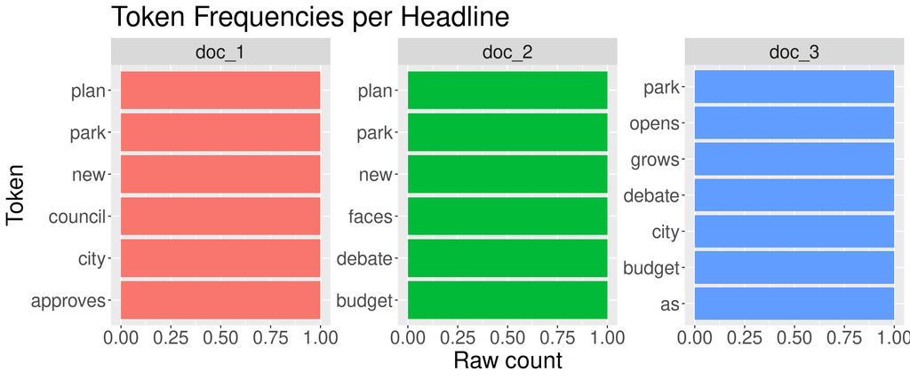

## Build a Count DTM

Count DTM

| term | doc_1 | doc_2 | doc_3 |
| --- | --- | --- | --- |
| approves | 1 | 0 | 0 |
| as | 0 | 0 | 1 |
| budget | 0 | 1 | 1 |
| city | 1 | 0 | 1 |
| council | 1 | 0 | 0 |
| debate | 0 | 1 | 1 |
| faces | 0 | 1 | 0 |

## Convert Counts to TF-IDF

- TF measures within-document concentration.
- IDF downweights globally common terms.
- TF-IDF combines both as `tf * idf`.
- We compute with `bind_tf_idf()`.
- Result emphasizes document-specific terms.

## Convert Counts to TF-IDF

TF-IDF long format

| document | term | count | tf | idf | tf_idf |
| --- | --- | --- | --- | --- | --- |
| doc_1 | approves | 1 | 0.167 | 1.099 | 0.183 |
| doc_1 | council | 1 | 0.167 | 1.099 | 0.183 |
| doc_1 | city | 1 | 0.167 | 0.405 | 0.068 |
| doc_1 | new | 1 | 0.167 | 0.405 | 0.068 |
| doc_1 | plan | 1 | 0.167 | 0.405 | 0.068 |
| doc_1 | park | 1 | 0.167 | 0.000 | 0.000 |
| doc_2 | faces | 1 | 0.167 | 1.099 | 0.183 |

## Compare Raw Counts and TF-IDF

- Raw counts and TF-IDF can rank terms differently.
- Shared terms keep count strength but lose weight.
- Distinctive terms gain relative importance.
- Comparison clarifies why weighting matters.
- Code uses selected columns for side-by-side view.

## Compare Raw Counts and TF-IDF

Raw count vs TF-IDF

| document | term | raw_count | tf | idf | tf_idf |
| --- | --- | --- | --- | --- | --- |
| doc_1 | approves | 1 | 0.167 | 1.099 | 0.183 |
| doc_3 | as | 1 | 0.143 | 1.099 | 0.157 |
| doc_2 | budget | 1 | 0.167 | 0.405 | 0.068 |
| doc_3 | budget | 1 | 0.143 | 0.405 | 0.058 |
| doc_1 | city | 1 | 0.167 | 0.405 | 0.068 |
| doc_3 | city | 1 | 0.143 | 0.405 | 0.058 |
| doc_1 | council | 1 | 0.167 | 1.099 | 0.183 |

## Extend df_texts with a Contrasting Topic

- We add a second theme to increase contrast.
- Civic and tech terms now coexist.
- Some words intentionally overlap across themes.
- This stresses weighting and topic boundaries.
- Core code is a six-row `tibble()` build.

## Extend df_texts with a Contrasting Topic

Six-document dataset with two themes

| doc_id | theme | headline |
| --- | --- | --- |
| doc_1 | civic | City council approves new park plan |
| doc_2 | civic | New park plan faces budget debate |
| doc_3 | civic | Budget debate grows as city park opens |
| doc_4 | tech | Tech firms race to launch new AI phone |
| doc_5 | tech | New AI phone sparks privacy debate debate |
| doc_6 | tech | Market analysts say tech stocks rise on AI |

## Read df_texts into a Corpus

- We convert text rows into a tm corpus object.
- Corpus stores text plus document identity.
- We summarize high-level corpus properties.
- This is the bridge to tm matrix casting.
- Code uses `VCorpus(VectorSource(...))`.

## Read df_texts into a Corpus

Corpus-level properties

| property | value |
| --- | --- |
| class | VCorpus |
| documents | 6 |
| total_characters | 227 |
| average_characters | 37.8 |

## Read df_texts into a Corpus

Document-level summary

| doc_id | headline | n_words | theme |
| --- | --- | --- | --- |
| doc_1 | City council approves new park plan | 6 | civic |
| doc_2 | New park plan faces budget debate | 6 | civic |
| doc_3 | Budget debate grows as city park opens | 7 | civic |
| doc_4 | Tech firms race to launch new AI phone | 8 | tech |
| doc_5 | New AI phone sparks privacy debate debate | 7 | tech |
| doc_6 | Market analysts say tech stocks rise on AI | 8 | tech |

## Cast Corpus to Count DTM and TF-IDF

- We clean text, then build `DocumentTermMatrix`.
- A second matrix applies TF-IDF weighting.
- Sparsity and weighting metadata are compared.
- This prepares features for downstream LDA.
- Code uses `DocumentTermMatrix()` and `weightTfIdf()`.

## Cast Corpus to Count DTM and TF-IDF

Object properties

| object | class | documents | terms | non_zero_cells | sparsity | weighting |
| --- | --- | --- | --- | --- | --- | --- |
| dtm_counts | DocumentTermMatrix | 6 | 24 | 38 | 0.736 | term frequency / tf |
| dtm_tfidf | DocumentTermMatrix | 6 | 24 | 38 | 0.736 | term frequency - inverse document frequency (normalized) / tf-idf |

## Cast Corpus to Count DTM and TF-IDF

Count DTM preview

| document | term | count |
| --- | --- | --- |
| doc_1 | approves | 1 |
| doc_1 | city | 1 |
| doc_1 | council | 1 |
| doc_1 | new | 1 |
| doc_1 | park | 1 |
| doc_1 | plan | 1 |
| doc_2 | budget | 1 |

## Fit LDA with Two Topics

- We fit `k = 2` topics on count DTM.
- TF-IDF is rescaled to pseudo-counts for LDA.
- Same random seed keeps comparisons stable.
- Output includes beta and gamma distributions.
- Code uses `topicmodels::LDA(..., method = "Gibbs")`.

## Fit LDA with Two Topics

LDA beta preview

| topic | term | beta |
| --- | --- | --- |
| 1 | debate | 0.1830 |
| 1 | ai | 0.1384 |
| 1 | budget | 0.0938 |
| 1 | city | 0.0938 |
| 1 | phone | 0.0938 |
| 1 | tech | 0.0938 |
| 1 | council | 0.0491 |

## Visualize Term Contribution to Topics

- Beta values rank terms within each topic.
- We compare count-based and TF-IDF-based models.
- Facets separate models and topic IDs.
- Top terms provide human-readable topic labels.
- Visualization emphasizes interpretability.

## Visualize Term Contribution to Topics

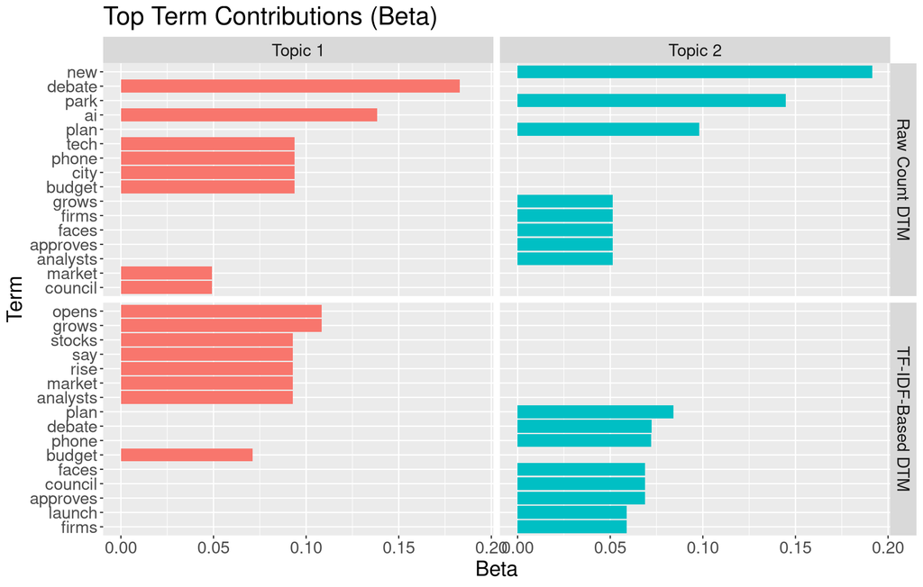

## Visualize Headline vs Topics

- Gamma values map documents to topics.
- Heatmap view shows mixture strength.
- Rows are headlines, columns are topics.
- Facets compare model variants.
- Cell labels make probabilities explicit.

## Visualize Headline vs Topics

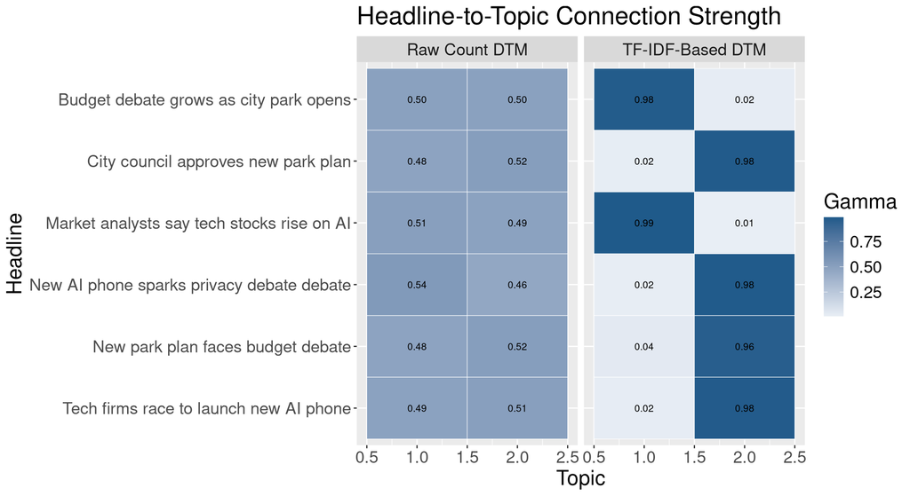

Scale up,  
Intro lab 2

## Corpus DTM and LDA Topic Tuning

- This part uses external `.txt` report files.
- We build a larger corpus and DTM.
- Topic count is tuned from 1 to 10.
- Coherence and confusion drive model selection.
- Final model is interpreted with beta/gamma.

## Corpus DTM and LDA Topic Tuning

Input files

| doc_id |
| --- |
| equinor01-protecting-the-environment.txt |
| equinor02-health-safety-and-security.txt |
| equinor03-human-rights.txt |
| equinor04-governance-and-transparency.txt |
| equinor05-our-transition-ambitions.txt |
| equinor06-a-just-energy-transition.txt |
| equinor07-environmental-social-and-governance-esg-reporting-centre.txt |

## Read Text Files into a Corpus

- All text files are loaded from `text-data`.
- File names become document IDs.
- Corpus stores raw text for preprocessing.
- We summarize size and length statistics.
- Code uses `read_file()` + `VCorpus()`.

## Read Text Files into a Corpus

Corpus properties

| property | value |
| --- | --- |
| documents | 9.0 |
| total_characters | 79033.0 |
| avg_characters | 8781.4 |
| total_words | 11441.0 |
| avg_words | 1271.2 |

## Cast File Corpus to Count DTM

- Text is cleaned and transformed to DTM.
- Rare terms are filtered by global bounds.
- Empty documents are dropped if needed.
- Sparsity confirms matrix structure.
- Frequent terms give quick topical hints.

## Cast File Corpus to Count DTM

Count DTM properties

| property | value |
| --- | --- |
| documents | 9.000 |
| terms | 618.000 |
| non_zero_cells | 1887.000 |
| sparsity | 0.661 |

Most frequent terms

| term | total_count |
| --- | --- |
| enno | 101 |
| energy | 93 |
| equinor | 59 |
| environmental | 49 |
| impact | 47 |
| transition | 46 |
| report | 42 |

## Tune Number of Topics

- We fit LDA for multiple `k` values.
- UMass coherence rewards semantic consistency.
- Topic confusion penalizes overlapping topics.
- A combined normalized score picks best `k`.
- `k=1` failure is expected and logged.

## Tune Number of Topics

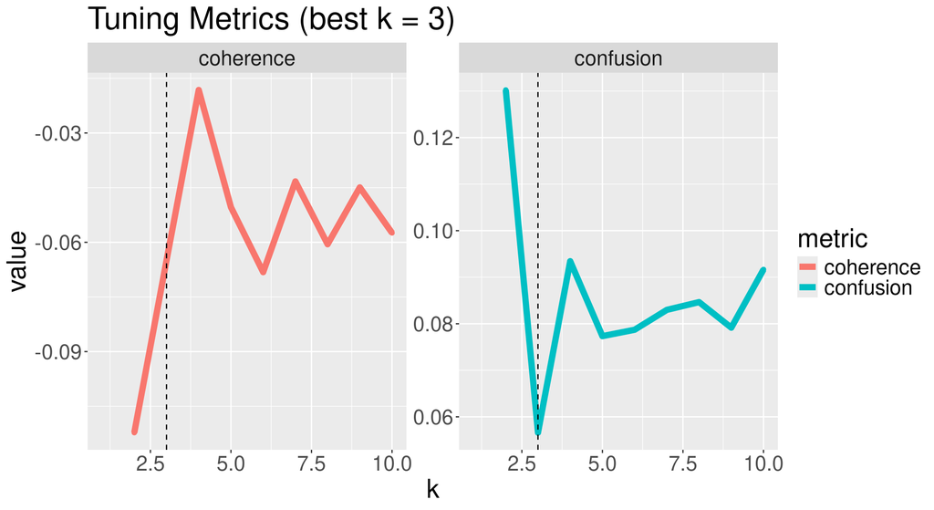

## Fit and Interpret the Best Topic Model

- Best model is selected from tuning results.
- Beta gives top terms per topic.
- Gamma gives topic probabilities per document.
- Together they support topic labeling.
- This is the final interpretive step.

## Fit and Interpret the Best Topic Model

Top topics per document

| document | topic | gamma |
| --- | --- | --- |
| equinor01-protecting-the-environment.txt | 2 | 0.4617 |
| equinor01-protecting-the-environment.txt | 3 | 0.3372 |
| equinor01-protecting-the-environment.txt | 1 | 0.2010 |
| equinor02-health-safety-and-security.txt | 3 | 0.7624 |
| equinor02-health-safety-and-security.txt | 1 | 0.1390 |
| equinor02-health-safety-and-security.txt | 2 | 0.0986 |
| equinor03-human-rights.txt | 3 | 0.7741 |

## Top Terms per Topic

- Topic terms come from highest beta scores.
- Each facet corresponds to one topic.
- Bars show term importance within topic.
- This view helps assign semantic labels.
- It supports qualitative model review.

## Top Terms per Topic

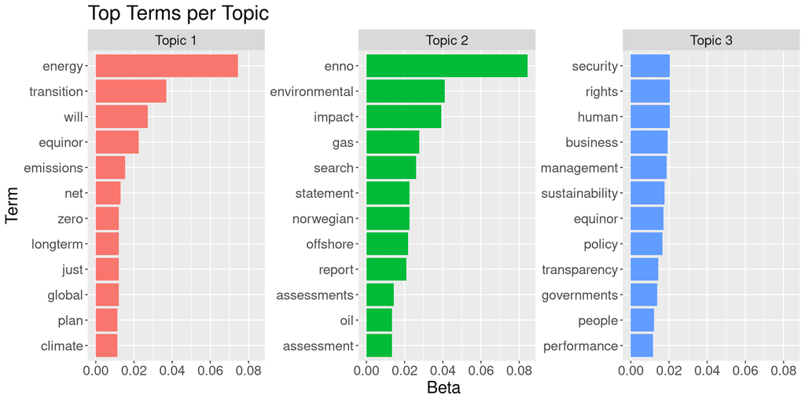

## Top Topics per Document

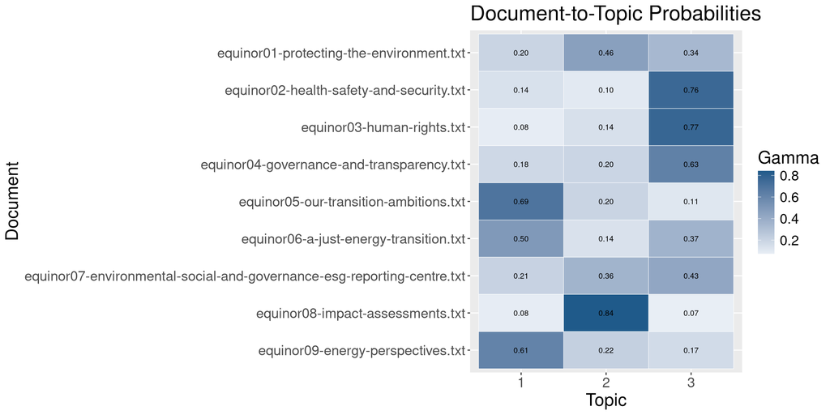

## Next steps

**Lecture 2 (feb 25), Lab 2 (feb 27)**

- Lecture notes: https://cca-cce.github.io/osm-comm/web/edu/simp59-lecture2-nlp.html
- Lab notebook: [check canvas page!](https://canvas.education.lu.se/courses/38911)

**References**

Silge, Julia, and David Robinson. 2017. *Text Mining with r: A Tidy Approach*. Sebastopol, CA: O’Reilly Media. https://www.tidytextmining.com/.

Wickham, Hadley, Mine Çetinkaya-Rundel, and Garrett Grolemund. 2023. *R for Data Science*. 2nd ed. "O’Reilly Media, Inc.". https://r4ds.hadley.nz/.

Wilke, Claus O. 2019. *Fundamentals of Data Visualization: A Primer on Making Informative and Compelling Figures*. O’Reilly Media. https://clauswilke.com/dataviz/.